# Factorial Analysis of Allergy Treatments

### Problem

Two new allergy treatments are being tested:

- An oral histamine blocker pill, once daily in the morning, at 4 doses: 0, 5, 10, and 15mg.
- A nasal corticosteroid spray, administered in three ways: never, once per day (morning only), and twice per day (morning and evening).

Subjects were recruited who lived in the same geographic area and all had verified allergic reactions to ragweed pollen. Every subject started the study at the same time (mid-August) and was on-study for 3 weeks. *Note: there might be a dependency problem here depending on the target population.* Subjects kept personal diaries where they rated individual aspects of symptoms, such as headache, runny nose, itchy eyes, etc. each day. These scores were combined over the 3-week period to get a single ’symptom score’ for each subject. A score of zero means no symptoms, and a larger score means worse symptoms.

The study goal is to analyze the data in such a way that it can answer these questions:

- What combination of therapies seems to give the best symptom relief? What other combinations, if any, are also good? What would be recommend to an allergy sufferer?
- Does one or the other therapy seem to be more important in reducing symptoms? Do the two therapies interact, and if so, what is the nature of the interaction?
- How can the design be improved to possibly increase the power of the study (apart from increasing sample size)?

Data:

- SubjectID: subject identification number.
- Oral: dose of oral histamine blocker the subject received, either 0, 5, 10, or 15mg of active ingredient.
- Nasal: frequency of nasal corticosteroid spray, either 0 (never), 1 (once per day), or 2 (twice per day).
- **SymptomScore**: symptom score for the subject. This is the response.

### Abstract

Two new allergy treatments are being tested. The study goal is to analyze the data and extract important information about the treatments combinations. The problem was modeled as a factorial treatment structure. Initial observations by an interaction plot indicated that both treatments reduce symptoms’ score and that there is interaction between them. The model was fitted and its assumptions of normality, constant variance, and linearity were met, but there might be a problem with independence depending on the study’s target population. Formal tests showed evidence of main effects for both treatments and antagonistic interaction. The oral treatment seems to be more important since it resulted in bigger main effect values. Fisher’s LSD was used to compare the means corresponding to all combinations. It showed no evidence that the best five groups (the ones with lowest symptoms’ score) have different symptoms’ relief between each other. Between these five groups, no nasal therapy and oral therapy with dose of 10 mg was chosen as the best combination since it is the simplest.

### First look at the data

As a **factorial treatment structure**, the data was plotted as an interaction diagram, where each point corresponds to the combination mean.

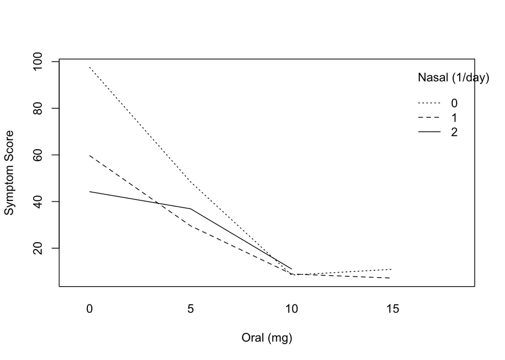

```r
# load data
data <- read.table("Allergy Data.txt", header = TRUE)
interaction.plot(data$Oral, data$Nasal, data$SymptomScore, fun = mean,
                 xlab = "Oral (mg)",ylab="Symptom Score",trace.label = "Nasal (1/day)")
```

The first thing that’s evident in the plot above is that as the oral dosage increases, the symptoms’ score seems to decrease, but maybe not between 10 and 15 mg. It is also apparent that as the nasal spray usage increased with an oral dose of 0 mg, the symptoms’ score decreased, but this affirmation can’t be done for combinations with oral dose bigger than 0. This, together with the fact that the lines are not parallel, indicate that there is interaction between the two treatments. These are provisional interpretations since they ignore the variability in the data.

### Model

A model for this data in a completely randomized design with a factorial treatment structure:
$$\text{score}_{ijl} = \mu + \text{nasal}_i + \text{oral}_j + (\text{nasal, oral})_{ij} + e_{ijl}$$

- $\mu$ = population grand mean.
- $\text{nasal}_i$ = main effect for $i$th level of factor nasal.
- $\text{oral}_j$ = main effect for $j$th level of factor oral.
- $(\text{nasal, oral})_{ij}$ = interaction effect for $j$th level of factor oral and for $i$th level of factor nasal.
- $e_{ijl}$ = error term.

The error terms are assumed to be independent and follow a normal distribution: $e_{ijl} \sim N(0,\sigma_e^2)$.

### Fitting the model and evaluating model assumptions

The model was fitted and a couple residual plots can be seen below. Everything looks fine there. All normality, constant variance, and linearity look good. Accordingly to how the experiment was described, there might be a problem with independence. This issue is discussed in the conclusion. For the data analysis here, it was considered the independence assumption as valid so this model could be used.

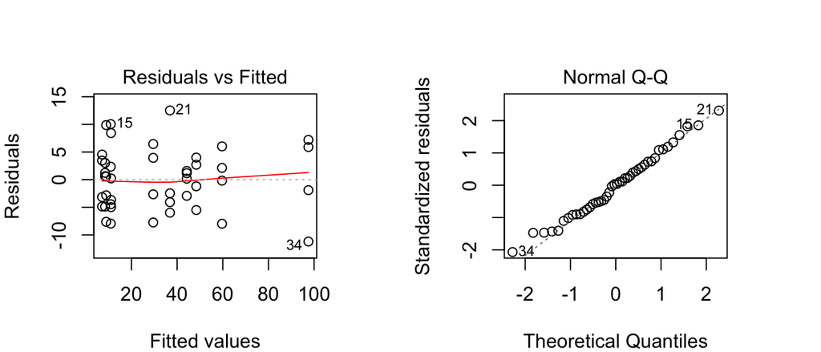

```r
# treatments as factors
nasal <- factor(data$Nasal, levels = c(0, 1, 2))
oral <- factor(data$Oral, levels = c(0, 5, 10, 15))
# fit model
mod <- lm(data$SymptomScore ~ nasal * oral)
# residual plots
par(mfrow=c(1,2), mar=c(4,4,4,4));plot(mod, which = 1:2)
```

```r
anova(mod)
```

```
## Analysis of Variance Table
##
## Response: data$SymptomScore
##            Df  Sum Sq Mean Sq F value    Pr(>F)
## nasal       2  1885.5   942.8  24.102 3.527e-07 ***
## oral        3 26484.2  8828.1 225.692 < 2.2e-16 ***
## nasal:oral  5  3942.6   788.5  20.159 3.524e-09 ***
## Residuals  33  1290.8    39.1
## ---
## Signif. codes:  0 '***' 0.001 '**' 0.01 '*' 0.05 '.' 0.1 ' ' 1
```

Test of the treatments interaction: $H_0:(\text{nasal, oral})_{ij}=0$ for all $i,j$ vs $H_A$: not $H_0$

From the ANOVA table above, $f = MS(nasal, oral)/MSError = 20.159$. Compared against an $F_{5,33}$ distribution: p-value = 3.524e-09. That is, there is strong evidence of a interaction between the treatments.

Proceeding hierarchically, since the interaction term should be in the model, the main effects should be retained even if they are not significant. But, for the purposes of understating better the model, the main effects were also tested

Test of the nasal treatment main effect: $H_0:(\text{nasal})_{i}=0$ for all $i$ vs $H_A$: not $H_0$

From the ANOVA table above, $f = MS(nasal)/MSError = 24.102$. Compared against an $F_{2,33}$ distribution: p-value = 3.527e-07. That is, there is strong evidence of a nasal treatment main effect.

Test of the oral treatment main effect: $H_0:(\text{oral})_{j}=0$ for all $j$ vs $H_A$: not $H_0$

From the ANOVA table above, $f = MS(oral)/MSError = 225.692$. Compared against an $F_{3,33}$ distribution: p-value < 2.2e-16. That is, there is strong evidence of an oral treatment main effect.

```r
summary(mod)
```

```
##
## Call:
## lm(formula = data$SymptomScore ~ nasal * oral)
##
## Residuals:
##     Min      1Q  Median      3Q     Max
## -11.200  -4.169   0.200   3.575  12.525
##
## Coefficients: (1 not defined because of singularities)
##               Estimate Std. Error t value Pr(>|t|)
## (Intercept)     97.500      3.127  31.179  < 2e-16 ***
## nasal1         -37.825      4.422  -8.553 6.96e-10 ***
## nasal2         -53.275      4.422 -12.047 1.26e-13 ***
## oral5          -49.100      4.422 -11.103 1.11e-12 ***
## oral10         -89.025      4.422 -20.130  < 2e-16 ***
## oral15         -86.550      4.422 -19.571  < 2e-16 ***
## nasal1:oral5    18.975      6.254   3.034  0.00468 **
## nasal2:oral5    41.750      6.254   6.675 1.34e-07 ***
## nasal1:oral10   38.275      6.254   6.120 6.78e-07 ***
## nasal2:oral10   55.875      6.254   8.934 2.52e-10 ***
## nasal1:oral15   34.025      6.254   5.440 5.03e-06 ***
## nasal2:oral15       NA         NA      NA       NA
## ---
## Signif. codes:  0 '***' 0.001 '**' 0.01 '*' 0.05 '.' 0.1 ' ' 1
##
## Residual standard error: 6.254 on 33 degrees of freedom
## Multiple R-squared:  0.9616, Adjusted R-squared:  0.9499
## F-statistic: 82.61 on 10 and 33 DF,  p-value: < 2.2e-16
```

Looking at the estimates above, two things are important to notice. The main effects for both treatments are negative for $i>0$ and $j>0$. That is, both methods to reduce the symptoms work by itself. Secondly, the interaction effect is always positive for $i>0$ and $j>0$. It characterizes an antagonistic interaction in terms of the symptoms’ score reduction. That is, the score reduction of the treatments combination is less than the sum of reductions caused by each treatment.

It can also be seen that the main effect for the oral therapy has bigger absolute value. it indicates that this therapy is more important in reducing symptoms.

### Fisher’s LSD in a group means approach

This problem can be seen as a group means problem with 11 groups. Fisher’s LSD can be used to compare the means corresponding to all combinations. For $\alpha = 0.05$:

```r
# code for getting lsmeans, library(emmeans)
lsmeans(mod, pairwise ~ nasal:oral)$lsmeans
```

Letter code display for LSD = 8.9672:

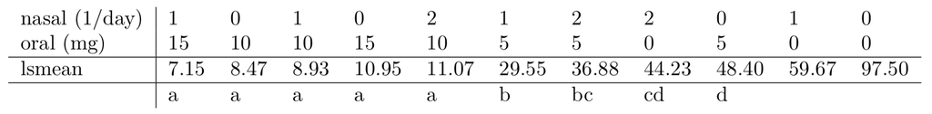

Important to notice that, for $\alpha=0.05$, there is no evidence that increasing the oral dosage from 10 mg to 15 mg reduces the symptoms’ score. None of the groups with oral dosage of 10 mg or 15 mg are significantly different from each other. There is evidence that, for oral dosage of 0 mg, increasing the nasal usage up to 2/day reduces the symptoms’ score.

### Conclusion

A first look at the data using an interaction diagram suggested that the two therapies have the main effect of reducing the symptoms’ score. It also suggested that there is interaction between the two treatments.

A model for this data in a completely randomized design with a factorial treatment structure was fitted. The normality, constant variance and linearity seemed fine. The f-tests taken from the ANOVA table showed strong evidence that there is interaction between the two treatments, and that there is strong evidence that each treatment has a main effect. The summary of the regression showed that the main effect for each treatment is negative. That is, they reduce the symptoms’ score.

The model has the assumption of independence between the observations. The experimental design might have a dependence problem because all the subjects are from the same geographical area and did the therapies at the same time. That is, there might be other factors that can cause dependence between the observations. For example, if one of the treatments is influenced by local climate, all the subjects were subjected to similar conditions. So, unless the study target population is people in that geographical area at that time of the year, this is a problem. If the study target population is more broad than that, the sample was drawn from an specific subgroup of the total population. Then, the generalization of this results for the entire population might be a problem.

As seen in the regression summary, this interaction can be categorized as antagonistic in terms of the symptoms’ score reduction. That is, the score reduction of the treatments combination is less than the sum of reductions caused by each treatment. It was also seen that the main effect for the oral therapy appears to be more important in reducing symptoms since it has larger absolute values.

Finally, Fisher’s LSD was used to compare the means corresponding to all combinations. It resulted in no evidence that increasing the oral dosage from 10 mg to 15 mg reduces the symptoms’ score. It also showed evidence that, for oral dosage of 0 mg, increasing the nasal usage up to 2/day reduces the symptoms’ score.

One way to improve the design of this experiment to detect significant main effects of treatments is to increase the power of the tests whether the main effects are significantly different from 0 (the f-tests shown in the ANOVA table). One way to do that is to increase the absolute value of the main effects. Based on the results seen, this can be done by concentrating the groups in the right bottom region of the interaction plot shown. For example, if all the groups with oral dose of 5 mg had an oral dose of 12.5 mg.